# 05 Tarea pronósticos

Author

Eddie Aguilar

```r
library("easypackages")
packages("tidyverse","fpp3", "tsibble", "feasts","fable", "patchwork")
library("USgas")
```

# Tarea

Series:

## 1. Serie de ventas de ropa en el Estado de Victoria, Australia

```r
(clothes_victoria <- filter(aus_retail, State == "Victoria", Industry == "Clothing retailing") |> select(Month, Turnover))
```

```
# A tsibble: 441 x 2 [1M]
      Month Turnover
      <mth>    <dbl>
 1 1982 Apr     93.6
 2 1982 May     95.3
 3 1982 Jun     85.2
 4 1982 Jul     91.6
 5 1982 Aug     85.2
 6 1982 Sep     89.5
 7 1982 Oct     93
 8 1982 Nov    108.
 9 1982 Dec    148.
10 1983 Jan     81.6
# … with 431 more rows
```

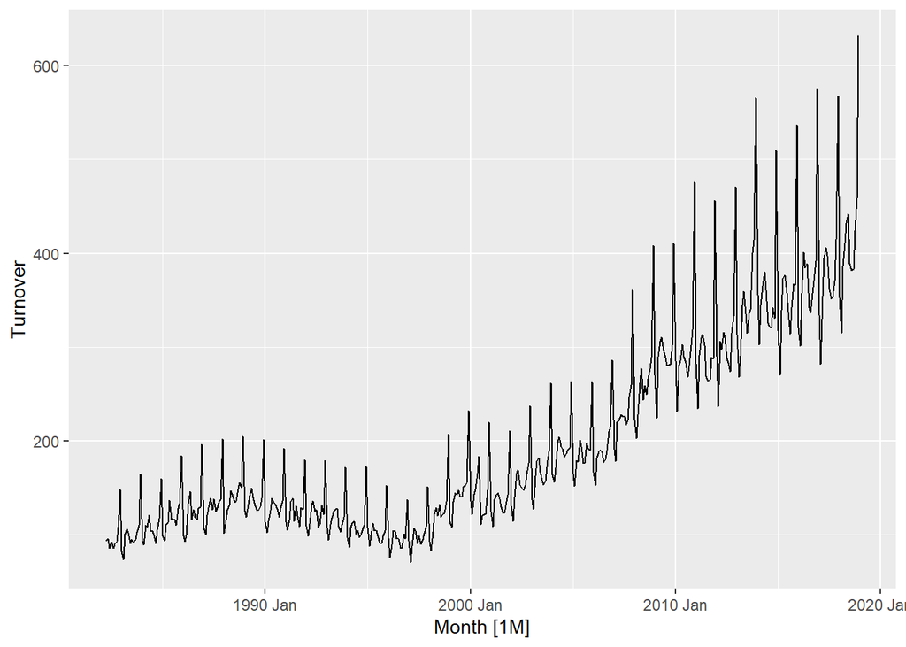

```r
train <- filter_index(clothes_victoria, "2000 Jan" ~ "2015 Dec")
autoplot(clothes_victoria, Turnover)
```

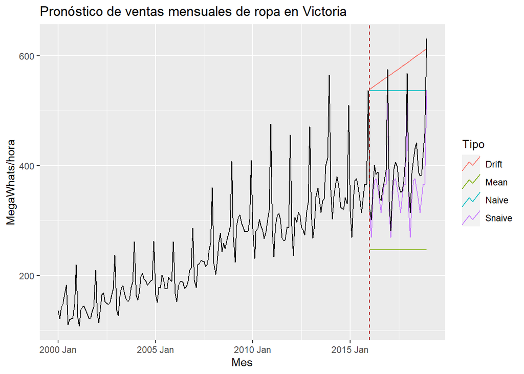

```r
fit <- model(train,
             Mean = MEAN(Turnover),
             Naive = NAIVE(Turnover),
             Snaive = SNAIVE(Turnover),
             Drift = RW(Turnover ~ drift()))

fc <- forecast(fit, h = "3 years")

fc |> autoplot(filter_index(clothes_victoria, "2000 Jan" ~ .), level = NULL) +
  ggtitle("Pronóstico de ventas mensuales de ropa en Victoria") +
  xlab("Mes") + ylab("MegaWhats/hora") +
  guides(color=guide_legend(title="Tipo")) +
  geom_vline(xintercept = as.Date("2016-01-01"), color = "firebrick", linetype = "dashed")
```

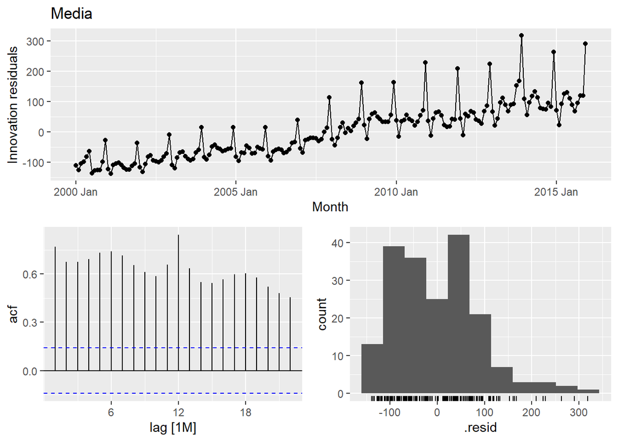

```r
select(fit, Mean) |> gg_tsresiduals() + ggtitle("Media")
```

La media no es buena idea, no muestra distribución normal del todo, están autocorrelacionados y la gráfica muestra un patrón.

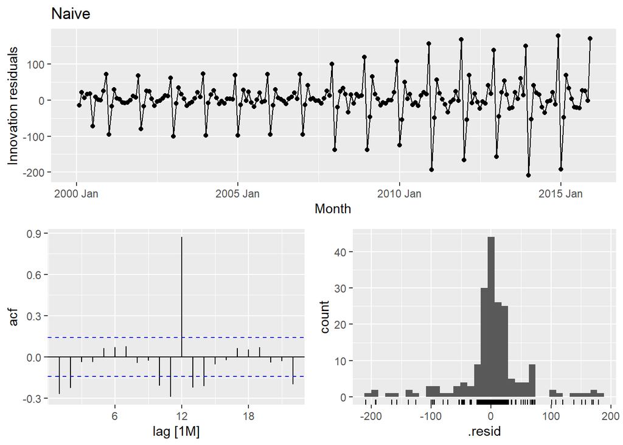

```r
select(fit, Naive) |> gg_tsresiduals() + ggtitle("Naive")
```

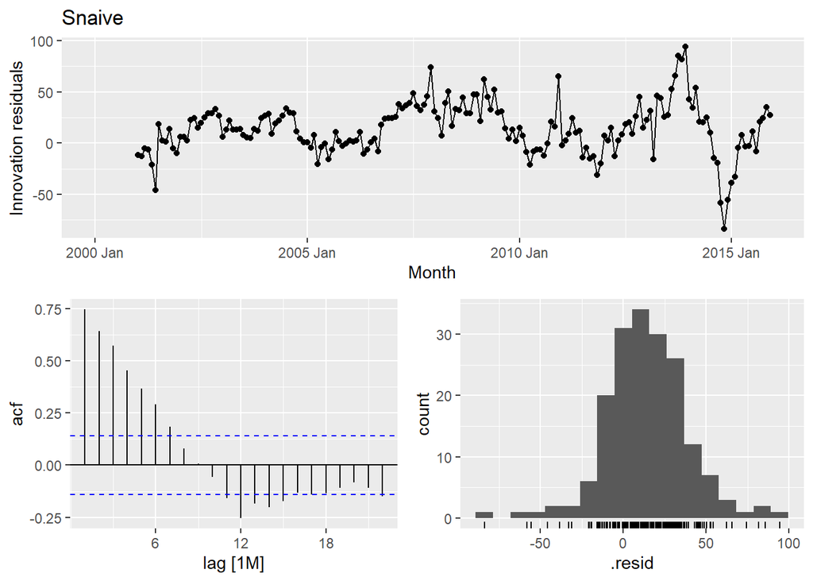

```r
select(fit, Snaive) |> gg_tsresiduals() + ggtitle("Snaive")
```

Snaive muestra distribución normal, sin embargo, parece presentar cierta correlación y patrón. A pesar de esto, Snaive sigue siendo un buen modelo al ver el gráfico.

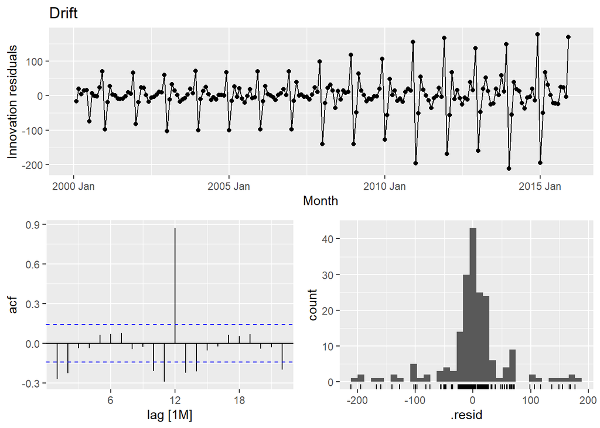

```r
select(fit, Drift) |> gg_tsresiduals() + ggtitle("Drift")
```

Drift tiene residuales muy similares a Naive, pueden ser buenas bases para aplicar otros modelos, sin embargo, tomando solo en cuenta los benchmark, probablemente Snaive será el que se va a utilizar.

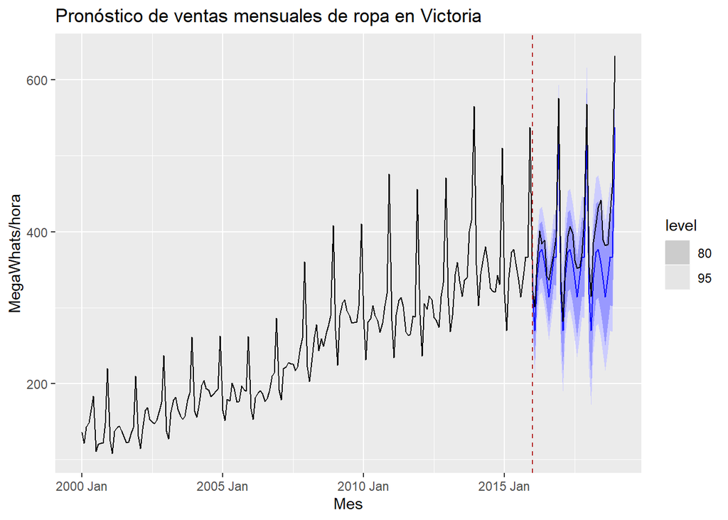

```r
fc <- filter(fc, .model == "Snaive")
fc_bs <- forecast(fit, h ="3 years", bootstrap = TRUE)
fc_bs <- filter(fc_bs, .model == "Snaive")

fc |> autoplot(filter_index(clothes_victoria, "2000 Jan" ~ .)) +
  ggtitle("Pronóstico de ventas mensuales de ropa en Victoria") +
  xlab("Mes") + ylab("MegaWhats/hora") +
  guides(color=guide_legend(title="Tipo")) +
  geom_vline(xintercept = as.Date("2016-01-01"), color = "firebrick", linetype = "dashed")
```

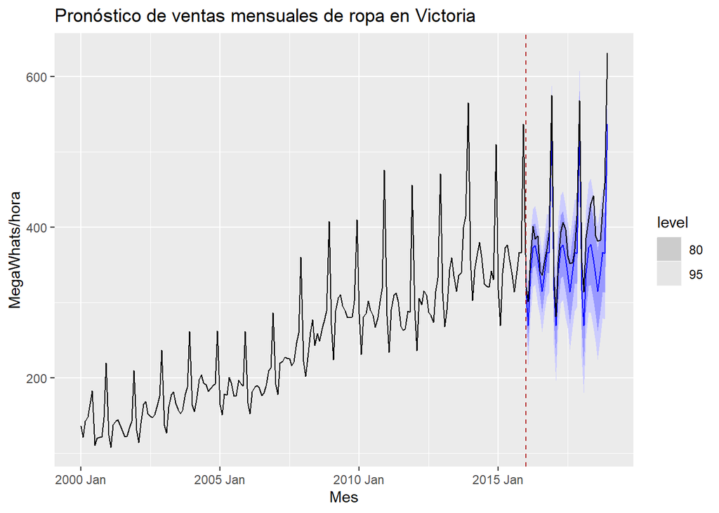

```r
fc_bs |> autoplot(filter_index(clothes_victoria, "2000 Jan" ~ .)) +
  ggtitle("Pronóstico de ventas mensuales de ropa en Victoria") +
  xlab("Mes") + ylab("MegaWhats/hora") +
  guides(color=guide_legend(title="Tipo")) +
  geom_vline(xintercept = as.Date("2016-01-01"), color = "firebrick", linetype = "dashed")
```

Al no ser datos muy aleatorios o los datos de una acción, y que los horizontes de pronóstico no son muy diferentes, no es necesario usar Bootstrap.

## 2. Serie de PIB per capita de Australia

```r
(aus_gdp <- filter(global_economy, Code == "AUS") %>%
   mutate(GDP_pc = GDP / Population) |> select(Year, GDP_pc))
```

```
# A tsibble: 58 x 2 [1Y]
    Year GDP_pc
   <dbl>  <dbl>
 1  1960  1807.
 2  1961  1874.
 3  1962  1851.
 4  1963  1964.
 5  1964  2128.
 6  1965  2277.
 7  1966  2340.
 8  1967  2576.
 9  1968  2719.
10  1969  2986.
# … with 48 more rows
```

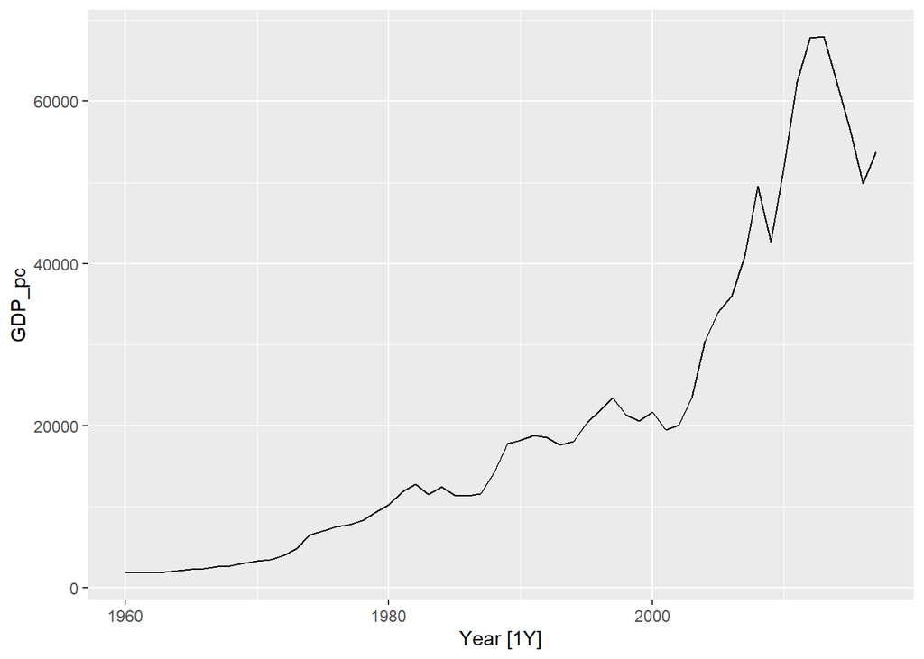

```r
train <- filter_index(aus_gdp, "1970" ~ "2010")
autoplot(aus_gdp, GDP_pc)
```

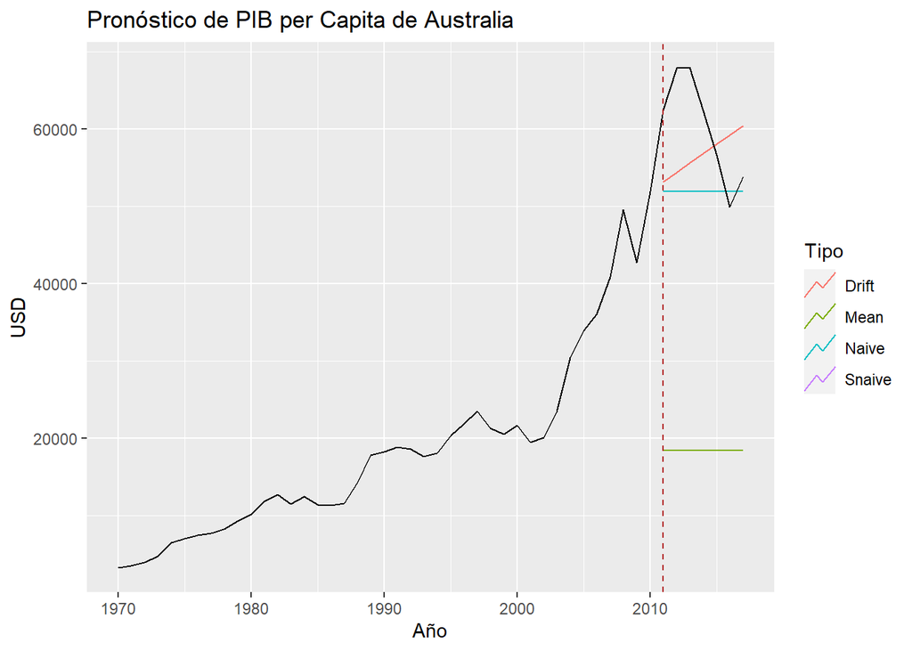

```r
fit <- model(train,
             Mean = MEAN(GDP_pc),
             Naive = NAIVE(GDP_pc),
             Snaive = SNAIVE(GDP_pc),
             Drift = RW(GDP_pc ~ drift()))
fc <- forecast(fit, h = "7 years")

fc |> autoplot(filter_index(aus_gdp, "1970" ~ .), level = NULL) +
  ggtitle("Pronóstico de PIB per Capita de Australia") +
  xlab("Año") + ylab("USD") +
  guides(color=guide_legend(title="Tipo")) +
  geom_vline(xintercept = 2011, color = "firebrick", linetype = "dashed")
```

Como podemos ver, Snaive no funciona al no ser estacional (se usan datos anuales)

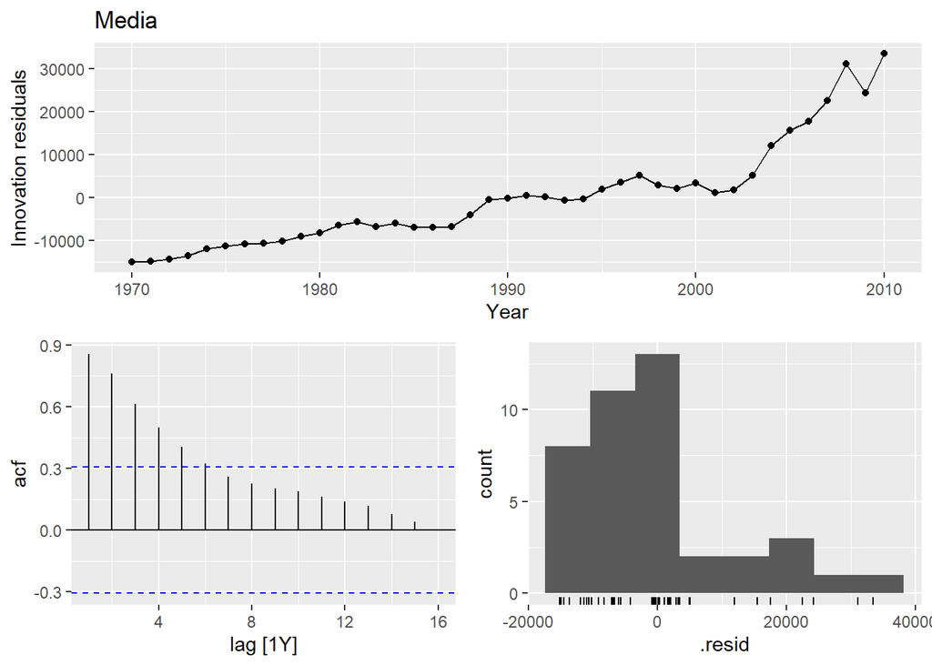

```r
select(fit, Mean) |> gg_tsresiduals() + ggtitle("Media")
```

La media no es buena idea, no muestra distribución normal, están autocorrelacionados y la gráfica muestra un patrón muy similar a los datos.

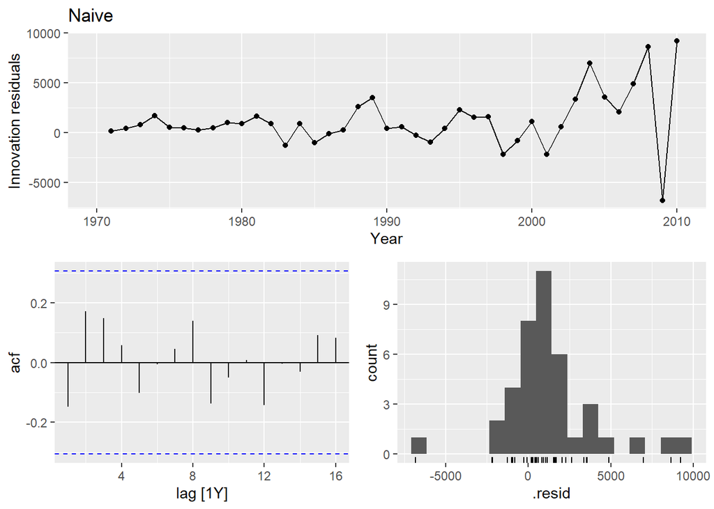

```r
select(fit, Naive) |> gg_tsresiduals() + ggtitle("Naive")
```

Naive parece ser la mejor opción, tiene distribución normal, y a pesar de no tener una varianza muy constante, es la mejor, y no parece estar muy correlacionado.

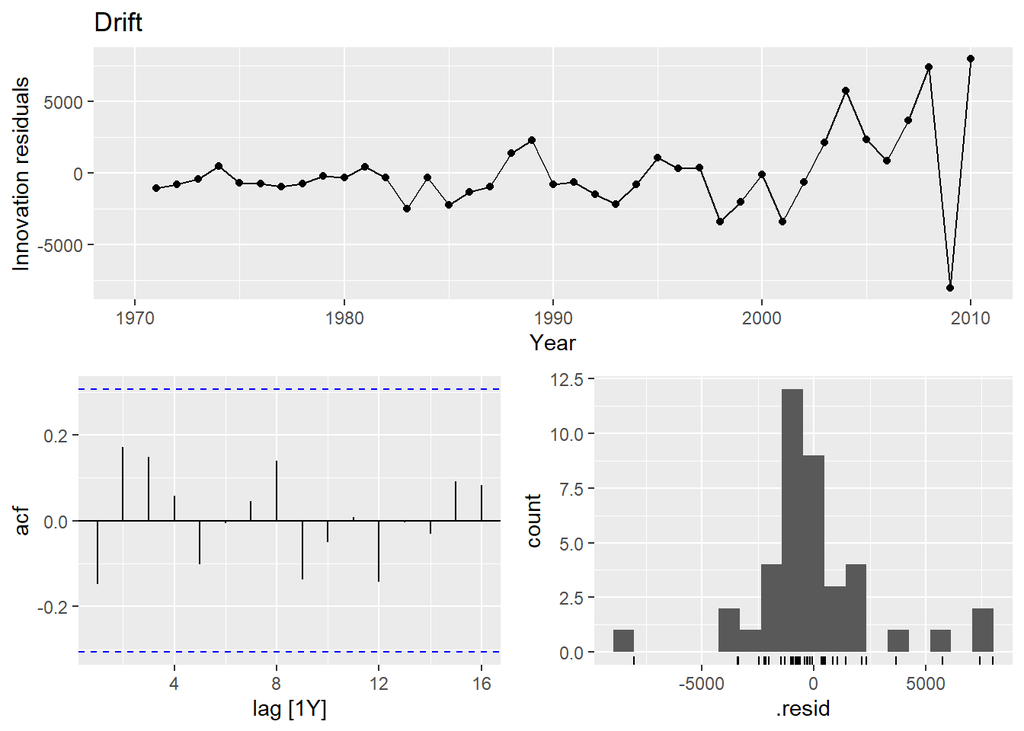

```r
select(fit, Drift) |> gg_tsresiduals() + ggtitle("Drift")
```

Drift tiene residuales muy similares a Naive, y tomando en cuenta las gráficas, se decide usar Drift para capturar la tendencia alcista que tiene.

Al no ser datos muy aleatorios o los datos de una acción, y que los horizontes de pronóstico no son muy diferentes, no es necesario usar Bootstrap.